# Introduction to R Markdown

Veronika Nechaeva

18 February, 2021

This assignment will introduce you to the `R Markdown` coding language. Moreover, this `R Markdown` file (note the *.rmd extension) is a setting called “literate programming” where a user can alternate between regular typing—enhanced with markdown—and computer code (`R` or `Python`). For reference, here is RStudio’s own [cheat sheet for R Markdown](https://rstudio.com/wp-content/uploads/2015/02/rmarkdown-cheatsheet.pdf)

Type your full name in the `author` field above. State your major (including emphasis if applicable) and list your classes—course number, course name, and discussion section number—below as an *ordered-list*, from the one you think will be the most difficult to the least difficult.

Major: Computer Science

1. MATH - 32 , Discussion 22D , Probability and Statistics
2. CSE - 15 , Lab - 08, Discrete Mathematics
3. CSE - 24, Advanced Programming
4. SPARK - 01, SPARK - Our Energy Future

Spend about 5 to 10 minutes typing out your answer to “What are you hoping to learn and gain from Math 32?” as a *bullet-point list*. Do not worry about grammar.

- Learn how to use RStudios
- Learn more probability concepts
- Learn to use RStudios to solve probability exercises

Spend about 5 minutes typing out your answer to “What are your fears and obstacles?” into the code block. Set the parameters `echo = FALSE` so that you do not show this part to your teachers and `eval = FALSE` so that RStudio does not treat the following as R code.

Please take a look at the quizzes that have been closed by Monday, February 15, 2021. Are there any questions you’d like us to go over? Please select up to 3 questions, place the quiz name (e.g., Video Quiz 2) between asterisks to *italicize* the quiz name and place the question number between two-pairs of asterisks so that the question number appears in **boldface**. If there is no question you’d like us to go over, please suggest a song to us. Place the song title between asterisks to *italicize* the song title and place the artist between two-pairs of asterisks so that the artist name appears in **boldface**. (Beyond profanity, please avoid offensive content.)

*Video Quiz 3* **Problems 5 and 9** *Video Quiz 2* **Problem 6**

The tasks below are about the binomial distribution.

# Commenting

Inside the code blocks, the typed information after the pound key (#) are called *comments*. Programmers use comments to remind themselves and teammates what each section of code does.

Run the following chunk of code, try to start to understand how the numbers, variables, and syntax go together. Write (at least) 5 comments inside the code block to demonstrate your understanding.

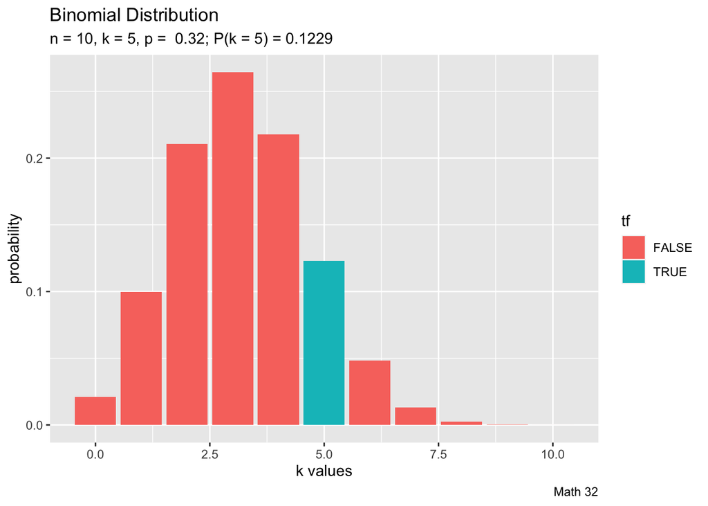

```r
# this is an example of a comment
n <- 10 # n is 10
k <- 5 # k is 5
p <- 0.32 # probability is 0.32

kvals <- 0:n
tf <- kvals == k
probabilities <- dbinom(kvals, n, p) # this is a binomial probability function
df <- data.frame(kvals, tf, probabilities) # frame function

custom_subtitle <- paste0("n = ", n, ", ",
                          "k = ", k, ", ",
                          "p =  ", p, "; ",
                          "P(k = ", k,
                          ") = ", round(dbinom(k,n,p), 4))

ggplot(df, aes(x = kvals, y = probabilities, fill = tf)) +
  geom_bar(stat = "identity") +
  labs(title = "Binomial Distribution",
       subtitle = custom_subtitle,
       caption = "Math 32",
       x = "k values",
       y = "probability")
```

# Sample Size

Keep the parameters $k = 5$ and $p = 0.32$, but build a couple of graphs for at least 2 different values of $n$, ($0 < k < n$), then write a sentence or two about what you observe with the graphs.

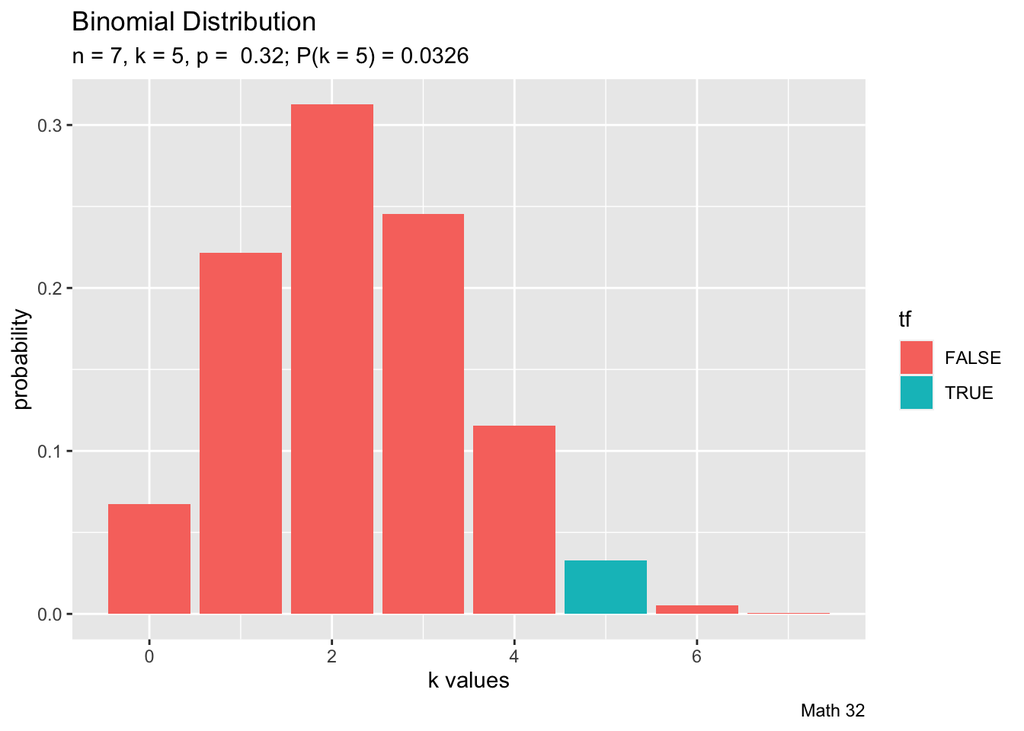

```r
# this is an example of a comment
n <- 7 # changed n
k <- 5
p <- 0.32

kvals <- 0:n
tf <- kvals == k
probabilities <- dbinom(kvals, n, p)
df <- data.frame(kvals, tf, probabilities)

custom_subtitle <- paste0("n = ", n, ", ",
                          "k = ", k, ", ",
                          "p =  ", p, "; ",
                          "P(k = ", k,
                          ") = ", round(dbinom(k,n,p), 4))

ggplot(df, aes(x = kvals, y = probabilities, fill = tf)) +
  geom_bar(stat = "identity") +
  labs(title = "Binomial Distribution",
       subtitle = custom_subtitle,
       caption = "Math 32",
       x = "k values",
       y = "probability")
```

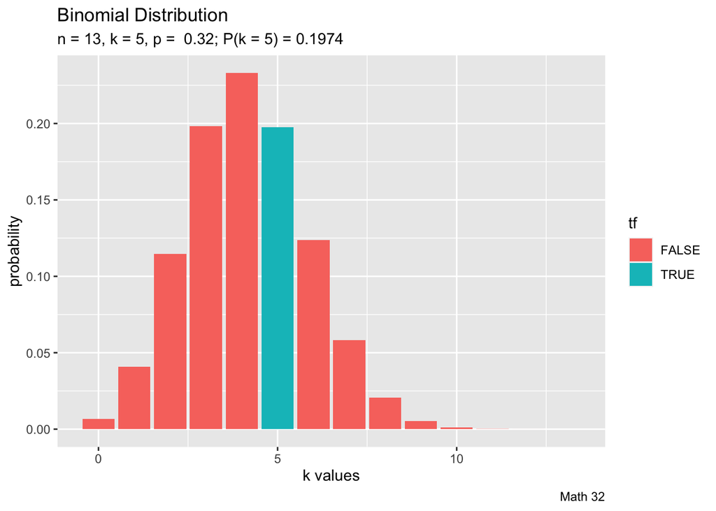

```r
# this is an example of a comment
n <- 13 # changed n
k <- 5
p <- 0.32

kvals <- 0:n
tf <- kvals == k
probabilities <- dbinom(kvals, n, p)
df <- data.frame(kvals, tf, probabilities)

custom_subtitle <- paste0("n = ", n, ", ",
                          "k = ", k, ", ",
                          "p =  ", p, "; ",
                          "P(k = ", k,
                          ") = ", round(dbinom(k,n,p), 4))

ggplot(df, aes(x = kvals, y = probabilities, fill = tf)) +
  geom_bar(stat = "identity") +
  labs(title = "Binomial Distribution",
       subtitle = custom_subtitle,
       caption = "Math 32",
       x = "k values",
       y = "probability")
```

Changing the value of n changes the variability. The bigger the n, the wider the graph is spread.

# Items Observed

Keep the parameters $n = 10$ and $p = 0.32$, but build a couple of graphs for at least 2 different values of $k$, ($0 < k < n$), then write a sentence or two about what you observe with the graphs.

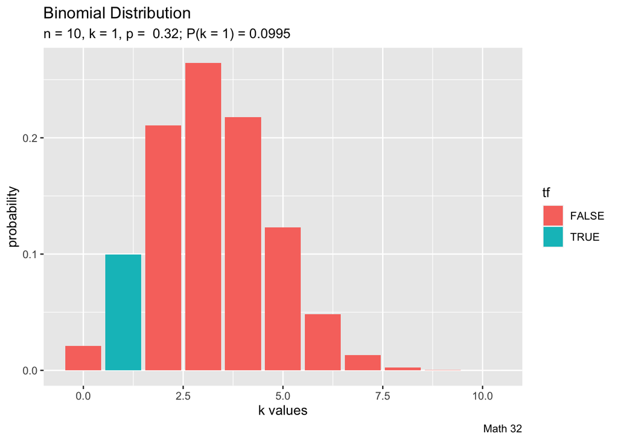

```r
# this is an example of a comment
n <- 10 # this is another comment
k <- 1
p <- 0.32

kvals <- 0:n
tf <- kvals == k
probabilities <- dbinom(kvals, n, p)
df <- data.frame(kvals, tf, probabilities)

custom_subtitle <- paste0("n = ", n, ", ",
                          "k = ", k, ", ",
                          "p =  ", p, "; ",
                          "P(k = ", k,
                          ") = ", round(dbinom(k,n,p), 4))

ggplot(df, aes(x = kvals, y = probabilities, fill = tf)) +
  geom_bar(stat = "identity") +
  labs(title = "Binomial Distribution",
       subtitle = custom_subtitle,
       caption = "Math 32",
       x = "k values",
       y = "probability")
```

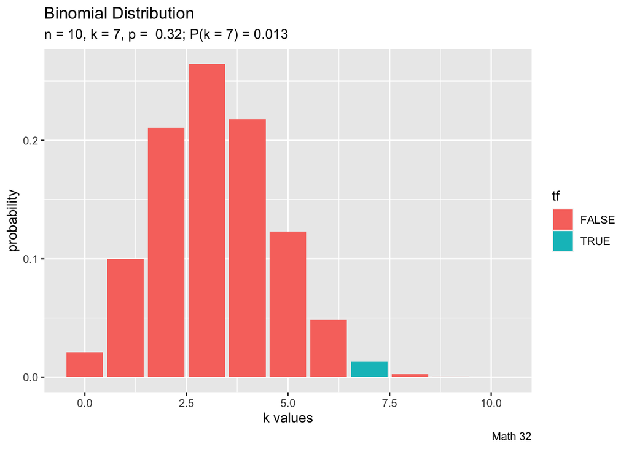

```r
# this is an example of a comment
n <- 10 # this is another comment
k <- 7
p <- 0.32

kvals <- 0:n
tf <- kvals == k
probabilities <- dbinom(kvals, n, p)
df <- data.frame(kvals, tf, probabilities)

custom_subtitle <- paste0("n = ", n, ", ",
                          "k = ", k, ", ",
                          "p =  ", p, "; ",
                          "P(k = ", k,
                          ") = ", round(dbinom(k,n,p), 4))

ggplot(df, aes(x = kvals, y = probabilities, fill = tf)) +
  geom_bar(stat = "identity") +
  labs(title = "Binomial Distribution",
       subtitle = custom_subtitle,
       caption = "Math 32",
       x = "k values",
       y = "probability")
```

The graphs are the same,however we are looking at different cases within the graphs. First case - P(k = 1), second - P(k = 7).

# Prior Probability

Keep the parameters $n = 10$ and $k = 5$, but build a couple of graphs for at least 2 different values of $p$, ($0 < p < 1$), then write a sentence or two about what you observe with the graphs.

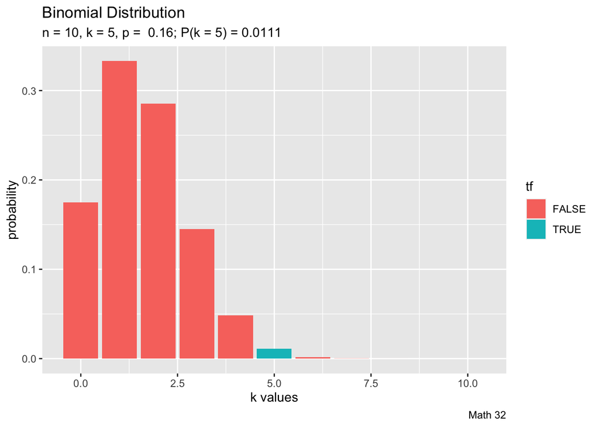

```r
# this is an example of a comment
n <- 10 # this is another comment
k <- 5
p <- 0.16

kvals <- 0:n
tf <- kvals == k
probabilities <- dbinom(kvals, n, p)
df <- data.frame(kvals, tf, probabilities)

custom_subtitle <- paste0("n = ", n, ", ",
                          "k = ", k, ", ",
                          "p =  ", p, "; ",
                          "P(k = ", k,
                          ") = ", round(dbinom(k,n,p), 4))

ggplot(df, aes(x = kvals, y = probabilities, fill = tf)) +
  geom_bar(stat = "identity") +
  labs(title = "Binomial Distribution",
       subtitle = custom_subtitle,
       caption = "Math 32",
       x = "k values",
       y = "probability")
```

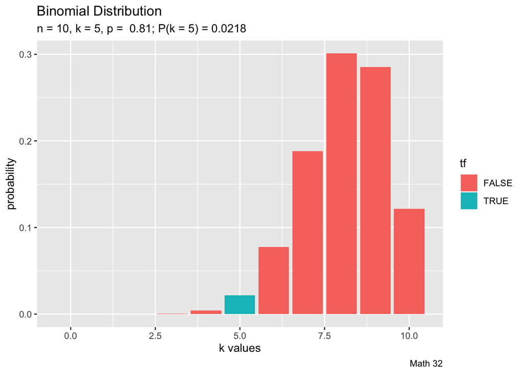

```r
# this is an example of a comment
n <- 10 # this is another comment
k <- 5
p <- 0.81

kvals <- 0:n
tf <- kvals == k
probabilities <- dbinom(kvals, n, p)
df <- data.frame(kvals, tf, probabilities)

custom_subtitle <- paste0("n = ", n, ", ",
                          "k = ", k, ", ",
                          "p =  ", p, "; ",
                          "P(k = ", k,
                          ") = ", round(dbinom(k,n,p), 4))

ggplot(df, aes(x = kvals, y = probabilities, fill = tf)) +
  geom_bar(stat = "identity") +
  labs(title = "Binomial Distribution",
       subtitle = custom_subtitle,
       caption = "Math 32",
       x = "k values",
       y = "probability")
```

Changing p changes the shape of the graph. If p is bigger than 0.5, the graph is skewed left. If the p is smaller than 0.5, the graph is skewed right. When the p is around 0.5, the graph seems to be evenly spread.

Save your work in the “Math32-Exploration-your name.rmd” convention, `knit` the code, and then upload the HTML file to CatCourses.